# Project Regression Methods - 2022

Céline Guex - sciper n°310673, Candice Baud - sciper n°359523

05 janvier 2023

# Introduction - Summary

# Initial data analysis

## Description of Fires dataset

This data set lists fires that occurred in French tunnels. The data set gathers 92 tunnels ran by 25 companies. Many parameters are also registered, like traffic, proportion of trucks among tunnel’s users (in %), length of the tunnel, maximum speed allowed,slope inclination in the tunnel (in %), shape of the tunnel (slope type in the tunnel) and situation of the tunnel (if it lies in urban area or not). Some tunnels are unidirectional and some are bidirectional. We will use this data set to determine the factors that are the most likely to yields to fires in tunnel. We will also look for factors that might reduce the risk of fires.

Figure 1 shows the distribution of the fires with a fitted poisson distribution, and the correlations between the different variables.We only display the variables that are the most correlated with the variable fires.

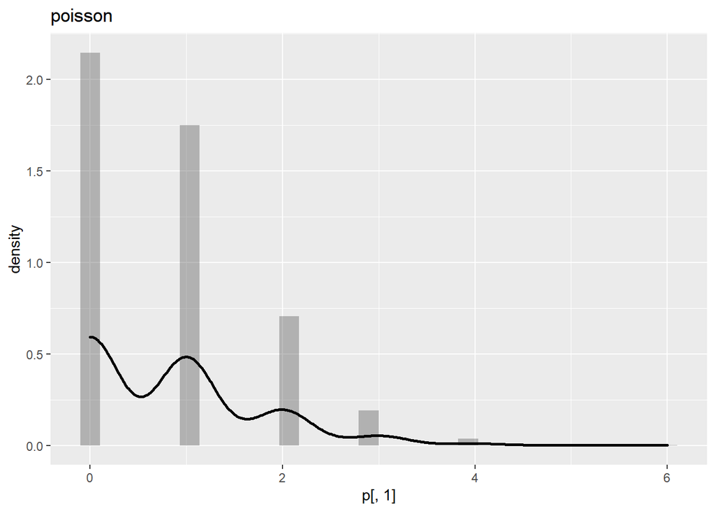

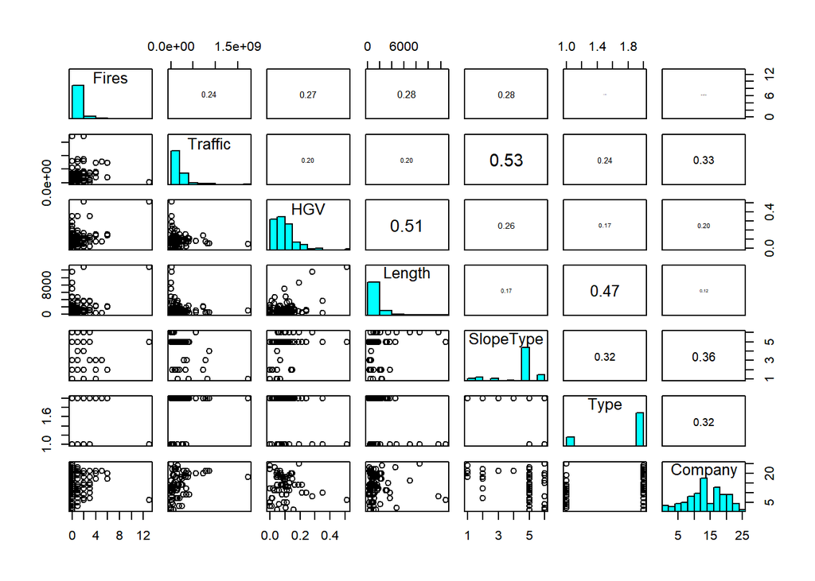

## Description of Accidents dataset

The accidents dataset gathers contains 92 tunnels ran by 25 companies. The variables from the dataset Fires are also present in the Accidents one. But the latter includes in addition the year in which the accidents occurred (variable Year), the width of lanes in the tunnel in metres (variable Width) and the number of lanes in the tunnel (variable Lanes).

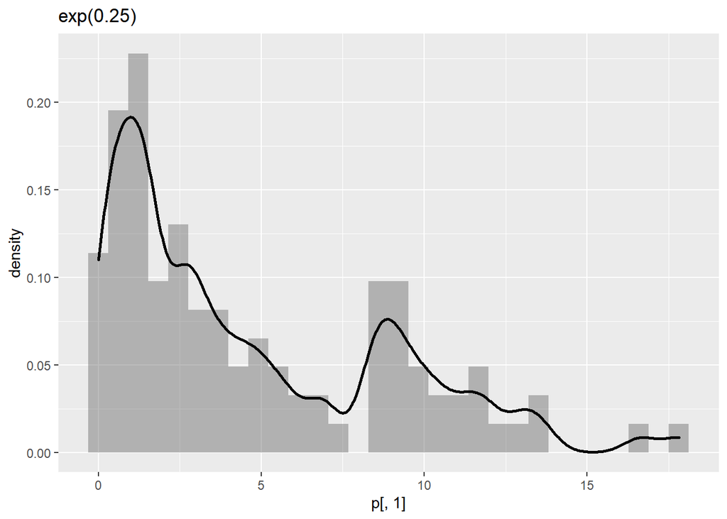

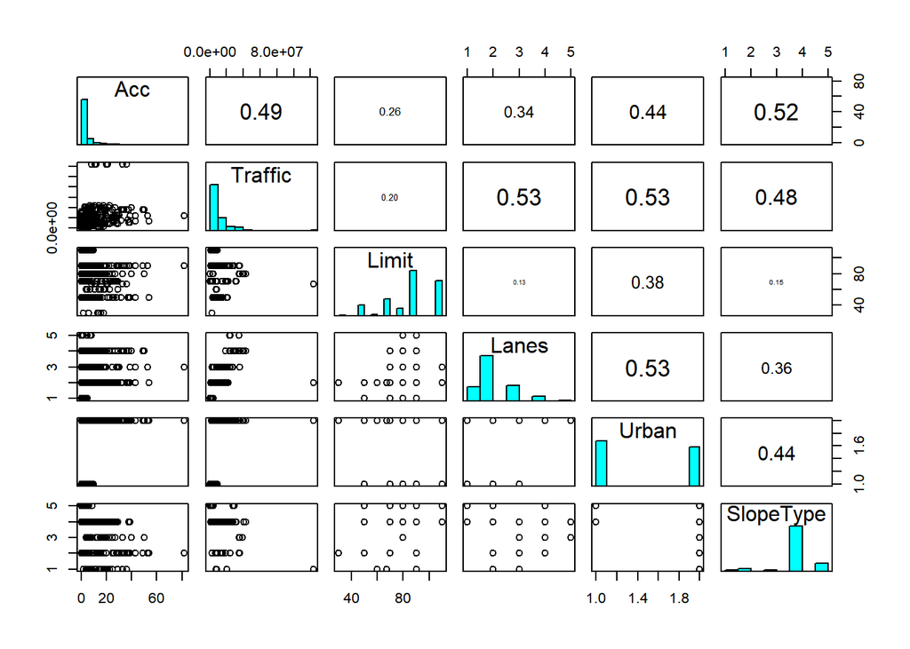

From this correlation analysis, the most important aspect to look at in this database is which variable truly has an impact on the number of accidents. Indeed, variables being quite correlated, it is important to dissociate the different effects to identify the real causal effects.